# Fixed-sample multi-arm clinical trial design

16/04/2019

#### Design setting

The trial will be designed to compare $K$ experimental treatments to a shared control arm. Response $X_{ik}$ from patient $i=1,...,n_k$ in arm $k=0,...,K$ will be assumed to be distributed as $X_{ik} \sim N(\mu_k,\sigma_k^2)$. Then, the hypotheses to be tested will be:
$$H_k : \tau_k = \mu_k - \mu_0 \le 0,\ k=1,...,K.$$
The global null hypothesis, $H_G$, will be given by:
$$\tau_1 = ... = \tau_K = 0.$$
The global alternative hypothesis, $H_G$, will be given by:
$$\tau_1 = ... = \tau_K = \delta_1.$$
The least favourable configuration for experimental arm $k$, $LFC_k$, will be given by:
$$\tau_k = \delta_1,\ \tau_1 = ... = \tau_{k-1} = \tau_{k+1} = ... = \tau_K = \delta_0.$$

2 experimental treatments will be included in the trial.

The standard devaiations of the responses, $\sigma_0,...,\sigma_K$, will be assumed to be: 1, 1, 1.

A significance level of 0.05 will be used, in combination with Dunnett’s correction.

The marginal power for each null hypothesis will be controlled to level 0.8 under each of their respective least favourable configurations.

The interesting and uninterresting treatment effects, $\delta_1$ and $\delta_0$ respectively, will be: 0.5 and 0.

The allocation to the experimental arms will be the same as the control arm.

The sample size in each arm will not be required to be a whole number.

#### Outputs

The total required sample size was computed as: 182.56.

The required sample size in each arm is: 60.853, 60.853, 60.853.

Thus, the realised allocation ratios to the experimental arms, $r_1,\dots,r_K$, are: 1, 1.

The following critical threshold should be used with the chosen multiple comparison correction: 0.028 .

The maximum familywise error-rate will be: 0.05.

The minimum marginal power will be: 0.8 .

| tau1 | tau2 | Pdis | Pcon | P1 | P2 | FWER | FDR |
| --- | --- | --- | --- | --- | --- | --- | --- |
| 0.0 | 0.0 | 0.0499926 | 0.0053217 | 0.0276572 | 0.0276572 | 0.0499926 | 0.0499926 |
| 0.5 | 0.5 | 0.9128494 | 0.6871506 | 0.8000000 | 0.8000000 | 0.0000000 | 0.0000000 |
| 0.5 | 0.0 | 0.8003278 | 0.0273294 | 0.8000000 | 0.0276572 | 0.0276572 | 0.0139925 |
| 0.0 | 0.5 | 0.8003278 | 0.0273294 | 0.0276572 | 0.8000000 | 0.0276572 | 0.0139925 |

### Plots

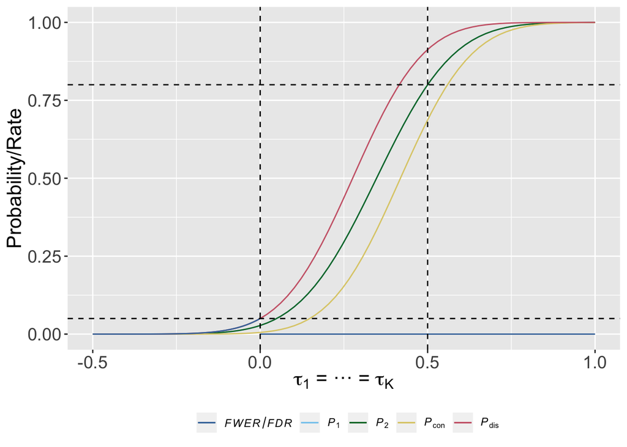

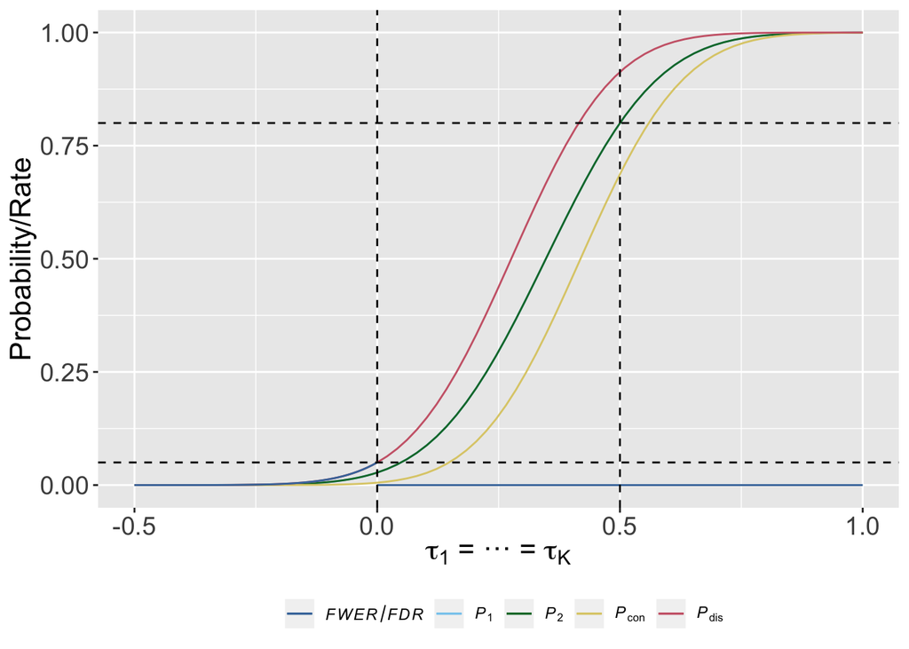